# Labor unemployment risk and corporate financing decisions

Page 1

### Labor unemployment risk and corporate financing decisions<sup>$</sup>

### Ashwini K. Agrawal <sup>a</sup>, David A. Matsa <sup>b</sup><sup>,</sup><sup>n</sup>

a The Stern School, New York University, United States b Kellogg School of Management, Northwestern University, United States

#### a r t i c l e i n f o

Article history: Received 27 January 2011 Received in revised form 25 May 2012 Accepted 16 July 2012 Available online 29 November 2012

JEL classification: G32 G33 J31 J65

Keywords: Capital structure Financial distress Unemployment risk Compensating wage differentials

#### a b s t r a c t

This paper presents evidence that firms choose conservative financial policies partly to mitigate workers’ exposure to unemployment risk. We exploit changes in state unemployment insurance laws as a source of variation in the costs borne by workers during layoff spells. We find that higher unemployment benefits lead to increased corporate leverage, particularly for labor-intensive and financially constrained firms. We estimate the ex ante, indirect costs of financial distress due to unemployment risk to be about 60 basis points of firm value for a typical BBB-rated firm. The findings suggest that labor market frictions have a significant impact on corporate financing decisions.

& 2012 Elsevier B.V. All rights reserved.

1. Introduction

Workers bear significant costs during unemployment. Unemployment risk is a substantial concern for workers: those

who are laid-off often endure significant reductions in consumption (Gruber, 1997), long delays before reemployment (Katz and Meyer, 1990), and significant wage cuts after returning to work (Farber, 2005; Gibbons and Katz, 1991). Displaced workers also suffer psychological and social costs (Kalil and Ziol-Guest, 2008; Kalil and DeLeire, 2010). Workers’ concerns about becoming unemployed reduce their labor supply (Brown and Matsa, 2012) and affect firms’ policies on layoffs and wage setting, even when they are far from bankruptcy (Topel, 1983, 1984; Li, 1986; Hamermesh and Wolfe, 1990). Despite their magnitude, however, workers’ costs of unemployment are largely absent from theories in corporate finance, which typically do not emphasize labor market frictions.

This paper studies the impact of worker unemployment costs on corporate financing decisions. Building on theories by Titman (1984) and Berk, Stanton, and Zechner (2010), we develop and examine the hypothesis that firms choose conservative financial policies partly as a means of mitigating worker exposure to unemployment

Contents lists available at SciVerse ScienceDirect

journal homepage: www.elsevier.com/locate/jfec

## Journal of Financial Economics

0304-405X/$ - see front matter & 2012 Elsevier B.V. All rights reserved. http://dx.doi.org/10.1016/j.jfineco.2012.11.006

$ For helpful comments, we thank the referee, David Autor, Jonathan Berk, Todd Gormley, Charles Hadlock, Samuel Lee, Steven Kaplan, Mark Leary, Gregor Matvos, Brian Melzer, Mitchell Petersen, Joshua Rauh, Michael Roberts, Philipp Schnabl, Morten Sorensen, Ilya Strebulaev, Amir Sufi, Sheridan Titman, David Yermack, and the seminar participants at Columbia University, DePaul University, the Federal Reserve Banks of Chicago and New York, New York University, Northwestern University, University of Missouri, University of Pennsylvania, University of Southern California, Temple University, Yale University, the Jackson Hole Finance Conference, the National Bureau of Economic Research Corporate Finance program, the Vanderbilt University Human Capital and Finance Conference, and the Washington University in St. Louis Corporate Finance Conference. We are also grateful to Ed Altman and Brenda Karlin for generously providing data on bond defaults.

n Corresponding author.

E-mail addresses: aagrawal@stern.nyu.edu (A.K. Agrawal), dmatsa@kellogg.northwestern.edu (D.A. Matsa).

Journal of Financial Economics 108 (2013) 449–470

Page 2

risk.<sup>1</sup> Workers require that firms provide a premium in wages or benefits as compensation for potential job loss (Topel, 1984; Abowd and Ashenfelter, 1981). Firms can choose financial policies that decrease the risk of financial distress and costly layoffs, which implicitly reduce the amount of compensation that workers require to offset unemployment risk. Diminished exposure to unemployment risk through flexible financial policy is likely to be especially important in industries that experience relatively high layoff separation rates and tight financing constraints, as workers in these industries are more likely to experience job loss caused by distress.

Empirical identification of the impact of workers’ exposure to unemployment risk on corporate financing decisions is challenging for two reasons. The first obstacle is the precise measurement of workers’ exposure to unemployment risk. The second difficulty is distinguishing the impact of worker unemployment costs from other factors that otherwise impact financial policy, such as unobservable investment opportunities. Correlations between leverage and proxies for unemployment risk, such as firm size, capital intensity, and wages, are suggestive but open to many interpretations (Verwijmeren and Derwall, 2010; Chemmanur, Cheng, and Zhang, 2009).

To overcome these challenges, we exploit changes in state unemployment insurance (UI) benefit laws and examine their relation with the corporate financial policies of US firms from 1950 to 2008. Increases in UI benefits impact corporate financing through their impact on workers’ exposure to unemployment risk. More generous state unemployment benefits make layoffs less costly and reduce workers’ demands that they be compensated by their employers for facing high unemployment risk (Topel, 1984). Because firms have less incentive to use conservative financial policy to reduce worker exposure to job loss, they are able to raise leverage and profit from increased debt tax shields and other benefits associated with debt financing.

Our approach enables us to identify the impact of shocks to unemployment risk on corporate financial policies without requiring explicit measures of worker risk aversion to unemployment. Legally mandated increases in unemployment insurance payments reduce the costs workers face when unemployed. Indeed, UI compensation has economically meaningful effects on workers’ behavior and on aggregate labor supply (e.g., Topel and Welch, 1980; Topel, 1984; Meyer, 1990, 1995; Meyer and Mok, 2007; Gormley, Liu, and Zhou, 2010). We verify that increases in state UI benefit generosity are associated with greater state UI payouts and thus provide meaningful shocks to workers’ exposure to unemployment risk.

Increases in the generosity of state unemployment insurance benefits are associated with higher firm leverage and lower interest coverage ratios. A 100 log point increase in the maximum total UI benefit is associated with firms

maintaining 4.5 percentage points greater average ratios of debt to assets and 15% lower interest coverage. These relations are empirically robust. The inclusion of controls for firm fixed effects implies that the results reflect average, within-firm changes in capital structure when states increase the generosity of their UI systems. Controls for year fixed effects account for concomitant national trends. We also include a variety of controls for firm financial characteristics and state economic conditions to ensure that the results are not driven by firm-level variation in performance or macroeconomic factors. The results are also robust to various alternate measures of UI benefit generosity. The relation between UI benefits and leverage becomes even stronger when we exclude firms that have a geographically dispersed workforce for which we are likely to measure eligible UI benefits with error.

The identification assumption central to the causal interpretation of these findings is that residual variation in UI benefits—after controlling for a number of factors, such as local economic conditions and firm characteristics—is uncorrelated with unobservable covariates that affect corporate leverage. An important concern that we evaluate in great detail is the possibility that unobserved variation in investment opportunities, or other factors that are not captured by our control variables, could explain changes in both UI benefits and firm leverage decisions. To evaluate the extent to which our estimates are biased by such unobserved heterogeneity, we perform a number of analyses. Collectively, the results of these analyses indicate that our findings are best explained through the channel of unemployment risk on corporate financing choices.

First, we show that the relation between UI generosity and leverage is particularly stark for subsamples of firms whose workers face greater expected unemployment costs. The relation is especially pronounced for firms in industries in which workers face greater risk of unemployment, such as industries with production technologies characterized by greater labor intensity and industries that experience frequent layoffs. Consistent with UI benefits being most beneficial for liquidity constrained workers (Browning and Crossley, 2001; Bloemen and Stancanelli, 2005; Chetty, 2008; Berk and Walden, 2010), the relation is also stronger for firms in industries that employ more low-wage workers and employees who do not own a home. Workers also vary in the speed with which they are able to secure reemployment after job loss because of either heterogeneous search costs or firm-specific human capital; workers who can quickly find employment after job loss often do not take any UI benefits (Anderson and Meyer, 1997). Consistent with employers of frequent UI recipients being more apt to consider UI law changes when making capital structure decisions, financing decisions in industries with many lowwage workers and frequent UI recipients are especially sensitive to changes in UI benefit laws.

Second, we find a stronger relation between UI generosity and leverage among firms that face tighter financing constraints, as measured by firm size, the absence of dividend payments, and low operating cash flows. Tight financing constraints make it difficult for firms to raise capital if they experience a negative shock, which raises the probability that such firms must resort to cost cutting through layoffs

1 As put by Stewart Myers, ‘‘To succeed a corporation requires a co-investment of financial capital from the outside and human capital that is built up inside the businessy. When you ask people to make an investment of human capital in your firm, you do not then do things—like raising the leverage ratio too high—that would needlessly put that investment at risk’’ (Myers, McConnell, Peterson, Soter, and Stern, 1998, pp. 18–19).

A.K. Agrawal, D.A. Matsa / Journal of Financial Economics 108 (2013) 449–470 450

Page 3

or reductions in wages and benefits (Ofek, 1993; John, Lang, and Netter, 1992). Workers in these firms are, therefore, likely to face greater unemployment risk, and increases in UI generosity should have a greater impact on the financial policies of these firms, as we show.

Third, we test a number of implications of alternate hypotheses that would suggest that our estimates reflect an endogenous, instead of a causal, link between unemployment risk and corporate leverage. We examine the timing of the relation between UI benefit changes and financial leverage and find that changes in leverage appear only after (not before) changes in UI benefit laws. This pattern indicates that the relation is not attributable to the generosity of UI benefit laws simply responding to worsening economic conditions or increases in corporate leverage. Furthermore, an unobservable variable, related to poor investment opportunities or poor unobservable economic conditions, would manifest in poor firm performance, but we instead find that firms show no signs of unusually low operating profits when residual benefits increase. We also show that the financing decisions of firms that generate most of their revenue from national commerce (and are, hence, unlikely to be driven by unobserved, local economic shocks) exhibit large, if not larger, sensitivities to UI laws than do firms that generate most of their sales from local, intrastate markets. Furthermore, as a falsification test, we show that bordering states’ UI benefit levels, which would also be affected by regional economic conditions, are not correlated with firms’ leverage. Additional tests, described later, reinforce a causal interpretation of the findings.

We also explore the empirical relevance of two alternate mechanisms that could potentially explain the observed link between UI benefits and leverage. One possibility is that increases in UI benefits raise firms’ UI premiums and other costs, leaving them with less money to pay back debt. However, when we examine the impact of increases in UI benefits on operating performance, we find that increases in UI benefits are not associated with decreases in performance. A second possibility is that unemployment insurance impacts the ability of unionized workers to bargain with management for higher wages, and in response, firms choose aggressive financial policies to toughen their bargaining position. We find, however, that the relation between UI generosity and financial policies is just as strong for firms with low union coverage.

Finally, we provide numerical estimates of the total indirect costs of financial distress due to unemployment risk. Although UI benefits provide substantial compensation to unemployed workers, they do not fully account for all costs borne by workers during layoff spells. Using data on employment changes for firms in default and estimates from Topel (1984) on the amount of compensation tied to unemployment risk, we estimate that the ex ante, indirect costs of financial distress that are due to unemployment risk compensation are large. An average BBB-rated firm pays workers about 60 basis points of the firm’s value to bear the layoff risk that is due to financial distress. For comparison, these costs explain nearly 90% of the difference between the tax benefits and risk-adjusted ex post costs of financial distress calculated by Almeida and Philippon (2007).

The central contribution of this paper is to provide novel empirical evidence that worker unemployment risk

significantly impacts firms’ corporate financial policies. The findings indicate that managers choose financial policy partly as a means of mitigating labor’s exposure to unemployment risk. More broadly, the evidence suggests that frictions in labor markets affect corporate financial policies, a phenomenon of growing interest as human capital becomes an increasingly critical asset for firms (Zingales, 2000). This paper adds to a growing literature that analyzes the interactions between labor economics and finance (including Matsa, 2010; Benmelech, Bergman, and Enriquez, 2012; Chen, Kacperczyk, and Ortiz-Molina, 2011). Whereas those papers examine leverage as a strategic input in the bargaining process between workers and firms, our paper examines a unique channel through which financial policy is used to mitigate the costs borne by workers as the result of involuntary unemployment.

2. Theoretical framework

Workers bear significant costs when they become involuntarily unemployed. These costs could result from costly job search (Diamond, 1982; Mortensen, 1986; Mortensen and Pissarides, 1994), layoff discouragement effects (Jahoda, 1982), a limited supply of match-specific job opportunities (Lazear, 2003), imperfect information about worker productivity (Harris and Holmstrom, 1982), or other labor market frictions. Whatever the underlying cause, the impact of these costs on worker and firm behavior is significant and has been studied extensively in labor economics. Given the high costs of unemployment, a number of theoretical and empirical papers find that workers require compensation in the form of higher wages, additional benefits, and improved working conditions to compensate for unemployment risk. These payments are commonly referred to as compensating wage differentials.

The idea that wage differentials must compensate workers for bearing unemployment risk dates back to 18th century Scottish economist Adam Smith (1976, p. 120):

The wages of labor in different occupations vary with the constancy or inconstancy of employmenty.What he earns, therefore, while he is employed, must not only maintain him while he is idle, but make him some compensation for those anxious and desponding moments which the thought of so precarious a situation must sometimes occasiony. The high wages of those workmen, therefore, are not so much the recompense of their skill, as the compensation for the inconstancy of their employment.

A number of theoretical papers formalize this idea and posit that workers face nontrivial costs of job mobility that impose constraints on short-run labor supply. Firms must compensate workers ex ante to bear these risks because they cannot fully commit to insuring workers against these costs (Abowd and Ashenfelter, 1981; Topel, 1984; Li, 1986; Rosen, 1986; Hamermesh and Wolfe, 1990). The risks—and, thus, the size of the compensation—increase with the probability of unemployment, the degree of worker risk aversion, the duration of job loss, and the costs incurred by workers during unemployment spells.

A.K. Agrawal, D.A. Matsa / Journal of Financial Economics 108 (2013) 449–470 451

Page 4

A variety of empirical evidence supports the importance of compensating wage differentials for unemployment risk. Abowd and Ashenfelter (1981) find that compensating differentials for unemployment risk vary across industries and are large (up to 14% of total wages) in the presence of significant unemployment risk. Topel (1984) estimates that a percentage point increase in anticipated unemployment raises an individual’s wage by about 1% in the presence of mean UI wage replacement. Li (1986) and Hamermesh and Wolfe (1990) find that 14–41% of total interindustry wage differentials can be explained by differences in unemployment risk.

Compensating wage differentials for unemployment risk are likely to affect firms’ financing policies. Financial leverage affects a firm’s probability of entering distress and, hence, impacts workers’ exposures to layoff risk, because distressed firms are often forced to lay off workers in order to meet outstanding debt obligations (Ofek, 1993; Asquith, Gertner, and Scharfstein. 1994). Increasing leverage can, therefore, raise the costs that are required to compensate workers for bearing greater exposure to the risk of financial distress and unemployment.

These considerations can be understood as an additional term in the trade-off weighed by firms when taking on additional leverage:

**equation / math rendering (image)**

**equation / math rendering (image)**

**equation / math rendering (image)**

In the traditional trade-off theory of capital structure, a firm that issues debt balances the value obtained from debt tax shields with the potential value lost should the debt cause the firm to encounter financial distress (for example, see Graham, 2000). The net present value (NPV) of the costs of financial distress is the product of the probability of financial distress times the magnitude of appropriately discounted, ex post direct and indirect costs of distress.

The contribution of this paper is to provide empirical support for the inclusion of an additional term in the adjusted present value equation that typically characterizes the trade-off theory of capital structure. Because debt financing increases the probability of layoffs in distress, it raises the compensation that workers require today to bear increased unemployment risk. While costs of financial distress typically refer to ex post costs that are realized if the firm eventually becomes financially distressed, the final term in Eq. (1) represents costs paid ex ante because of labor market frictions.<sup>2</sup>

Workers’ demands for higher wages, when their firms take on increased financial risk, do not require that workers directly observe firms’ leverage decisions. The impact of leverage on unemployment risk is likely to be manifest in informative signals from coworkers, management, the media, and from other aspects of the economic environment. Using survey responses, Brown and Matsa (2012) find that job seekers accurately perceive firms’ financial health.

If outside job seekers can perceive such changes in distress risk, the firm’s employees likely perceive these changes as well. The evidence that compensating wage differentials do in fact respond empirically to unemployment risk further supports this conclusion (Abowd and Ashenfelter, 1981; Topel, 1984; Li, 1986; Hamermesh and Wolfe, 1990).

In the empirical analysis that follows, we examine changes in workers’ unemployment insurance benefits as shocks to the final term in Eq. (1). Because unemployment is less costly when workers are eligible for more generous UI benefits, they require a lower compensating differential per unit of layoff risk. For example, Topel (1984) finds that unemployment insurance significantly reduces wage premiums for unemployment risk and estimates that the full replacement of wages by UI payments would cause compensating wage premiums to decline to zero. The reduced wage premiums enable firms to raise leverage and gain from increased debt tax shields, lower managerial agency costs, and other benefits associated with debt financing.

3. Institutional background

The unemployment insurance system of the United States provides temporary income to eligible workers who become involuntarily unemployed. Under the joint federal-state system, created by Congress in 1935, the basic framework for insurance provision is common nationwide, but each state has the autonomy to set a number of the program’s parameters, including the amount of benefits paid to unemployed workers.

Each state’s unemployment insurance benefits has three key features: eligibility, wage benefit amounts, and duration. Typically, all private sector workers who are involuntarily unemployed and actively seeking new employment are eligible for benefits. The wage benefit provided to an eligible worker is set in accordance with formulas that are determined by state law. A state’s wage benefit formula typically calculates the highest earnings realized by the worker in four of the last five quarters and seeks to replace approximately 50% of those wages through weekly payments, subject to minimum and maximum bounds. Much of the variation in insurance benefits, across states and over time, stems from changes to the maximum bounds. States also vary in the duration of time for which the claimant is eligible to receive weekly payments.

Unemployment insurance provisions are mostly financed by taxes assessed on eligible firms and aggregated over time into individual state trust funds. Currently, almost all firms that employ at least one worker for 20 weeks and maintain minimal levels of base wage payments are subject to unemployment insurance taxes. Tax rates are experience rated, that is, firms with a history of more worker unemployment claims pay higher tax rates. When a claimant files for UI benefits, payments are first made by state governments. After states exhaust their resources or hit certain rates of aggregate unemployment, they are eligible to tap into federal funds for additional support.

A number of factors lead to variation in unemployment insurance benefits across states and over time (Blaustein, 1993). Underlying economic conditions play a critical role. For example, the degree of a state’s industrial urbanization,

2 Leverage can impose ex ante costs on the firm through the product market as well. For example, Titman (1984) and Opler and Titman (1994) argue that high leverage potentially reduces sales of long-lived goods because customers that anticipate a bankruptcy liquidation expect higher costs of parts and servicing.

A.K. Agrawal, D.A. Matsa / Journal of Financial Economics 108 (2013) 449–470 452

Page 5

underlying trends in local unemployment rates, and higher average wage levels are commonly associated with benefit increases. A number of noneconomic factors also affect changes in UI benefits. Political forces, such as reelection concerns by incumbent officials, haggling and logrolling within legislative bodies, party preferences, and lobbying efforts by various constituencies, have historically been important determinants of many UI law changes.

Several historical episodes illustrate that various factors, unrelated to economic conditions, affect changes in unemployment insurance laws. For example, in 2002, California passed its first increase in unemployment benefits in more than a decade. Amid economic fluctuations during the prior ten years, the maximum weekly benefit was held constant at $230. In 2002, the maximum weekly benefit was raised to $330. The increase in UI benefits appeared timed with yearend gubernatorial elections as it bolstered political support for the governor’s reelection (Kiplinger California Letter, 2001; Oakland Tribune, 2002). In another instance, New York increased its UI benefits by 36% in 1990, the first increase in 5 years. The long delay and eventual large adjustment were tied to political haggling over unrelated workers’ compensation and other laws (New York Times, 1989). As a third example, Maine increased its maximum UI benefits by approximately 12% in 2000. The increase appeared to be unrelated to the prevailing economic climate. Instead, the change was described as overdue legislation delayed as the state’s Labor Committee faced unrelated, more immediate issues (Portland Press Herald, 1999; Bangor Daily News, 1999).

UI benefits have a substantial impact on unemployed workers. Gruber (1997) finds that unemployment insurance provides significant consumption smoothing benefits to workers. In the absence of unemployment insurance, Gruber estimates that consumption would fall by onethird. Gormley, Liu, and Zhou (2010) conclude that unemployment insurance impacts workers’ personal savings and investment decisions. Increases in unemployment insurance benefits also affect workers’ searches for new employment and the durations of their unemployment spells (Topel and Welch, 1980; Moffitt, 1985; Meyer, 1990, 1995; Meyer and Mok, 2007). The impact of UI benefits on unemployed workers, in turn, appears to have significant effects on firms. For example, managers are more willing to lay off workers when benefits improve and workers face lower costs of unemployment (Topel, 1983).

Changes in the generosity of unemployment insurance benefits thus provide meaningful shocks to the cost to workers of being laid off. We use these shocks, which feature substantial heterogeneity across states and over time, to examine whether firms account for workers’ exposure to unemployment risk in setting their financial policies. Variation in unemployment insurance laws affects workers’ expected outcomes in unemployment without directly impacting the firm itself and, thus, provides a clean setting to examine the relation between financial policy and workers’ exposure to unemployment risk.

4. Data and empirical framework

Raw data suggest that worker unemployment costs affect firm financial policy. Fig. 1 shows the industry-level

correlation between layoff propensities and market leverage ratios. The worker layoff separation rates are long-run averages from the US Bureau of Labor Statistics ‘‘Mass Layoff Statistics’’ (see Appendix A for details), and average market leverage is from Compustat for 2008. The graph shows a negative relation between layoff propensities and leverage. The negative relation is consistent with greater layoff propensities exposing workers to greater unemployment risk, which, in turn, causes managers in these industries to choose conservative financial policies to protect workers from unemployment. Similarly, Titman and Wessels (1988) find a positive correlation between voluntary employees’ quit rates and firms’ leverage ratios. They conclude that low costs of job loss lead to greater voluntary unemployment and allow firms to increase debt financing.

However, the statistical relations between layoffs, quit rates, and capital structure might not reflect causal relations. High industry volatility, for example, could lead to both high layoff propensities and conservative financial policies. To more precisely measure and identify the impact of worker unemployment costs on financial policy, we collect data on state UI benefit laws and firm balance sheet characteristics. Information on UI benefits is from the US Department of Labor’s ‘‘Significant Provisions of State UI Laws’’ from 1950 through 2008. These annual publications detail the UI benefit schedules in each state. Under each system, eligible claimants receive a weekly benefit payment for a specified number of weeks, where the benefit amount and duration are determined by the worker’s employment history during a base period. To measure the generosity of each state’s UI system, we focus on the product of the maximum benefit amount and the maximum duration allowed.<sup>3</sup> The results are robust to other specifications for the generosity of the benefit criteria.

Summary statistics that describe the generosity of unemployment insurance benefits are presented in Table 1. Log max weekly benefit is the natural log of the maximum weekly wage benefit allowance given to workers in an average state-year. The average log wage benefit, unadjusted for inflation, is 5.2 (approximately $186 per week). Log max duration is the natural log of the maximum number of weeks that a state provides unemployment insurance benefits to claimants. The average sample state-year amount is 3.3 (approximately 26 weeks). Log max total benefit, the natural log of the maximum number of weeks times the maximum weekly benefit amount, provides a proxy for the total UI benefits that a UI claimant can receive in a given year (US Congress, US House of Representatives, 2004). Unadjusted for inflation, the average of log max total benefit is 8.5 (approximately $4,900 per

3 Much of the empirical research on UI generosity examines variation across individual workers in the ratio of the weekly UI benefit to weekly wages, which is called the wage-replacement ratio. Although the wagereplacement ratio naturally derives from theoretical models of job search, it varies relatively little either across state programs or over time (Moffitt and Nicholson, 1982). Because our study focuses on differences in UI across firms (and we lack employer–employee linked data), we rely on characteristics of UI generosity that display significant variation across states and over time. These provisions are also directly relevant to policy makers, as they have proven flexible in practice.

A.K. Agrawal, D.A. Matsa / Journal of Financial Economics 108 (2013) 449–470 453

Page 6

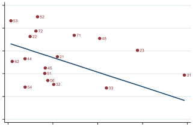

year). Significant variation also exists across states. In 2009, for example, the maximum total benefit over an unemployment spell varies from about $6,000 in Mississippi to more than $28,000 in Massachusetts.

The evolution of state UI benefits over time is graphically depicted in Figs. 2 and 3. Fig. 2 illustrates relative increases in state maximum UI benefits by decade. Each map corresponds with a different decade and displays the quartile of each state’s increase in UI generosity; darker shading indicates larger increases in UI benefits. States display significant heterogeneity in relative UI benefit trends across decades, and within decades, the variation does not appear to be caused by regional trends. The changes in UI benefits are not dominated by a specific group of states. At some point, all states experience large changes in UI benefit laws relative to their peers. Fig. 3 plots the distribution of the absolute magnitude of the changes in state UI benefit laws over each decade. States typically increase their UI generosity by 25–75% over a decade, and much larger increases, such as more than doubling maximum total benefits, are not uncommon.

No indication exists that states change UI benefit laws at the same time that they adopt other laws that impact corporate debt capacity. To explore a possible connection, we compare changes in UI generosity with changes in state corporate income tax rates, as tax rates are, perhaps, the most important drivers of corporate leverage choices. We obtain data on states’ highest marginal corporate income tax rate from the US Tax Foundation for the years 2000– 2009. Although the tax rate and log max total benefit display similar amounts of variation across states and over time, the partial correlation between the series, after accounting for state and year fixed effects, is only 0.0089 (pZ0.85). The changes in these laws thus appear to be unrelated.

The measures of UI generosity that we construct are reflected in the aggregate realized value of UI benefits paid by states. Using annual data on state UI payments from 1969 (the earliest year available) through 2008 from the US Bureau of Economic Analysis (BEA) ‘‘Regional Economic Accounts,’’ we regress the natural log of total UI compensation on the benefit criteria previously described, as well as controls for macroeconomic conditions and state and year fixed effects. The results, reported in Table 2, indicate that the elasticity of maximum total benefits to actual compensation payments is approximately 0.9. Aggregate payouts are also correlated with states’ maximum weekly benefit amounts and maximum duration periods. The correlations are statistically significant and economically meaningful and robust to controls for macroeconomic conditions, as represented by the state unemployment rate (calculated from Current Population Survey microdata using state identifiers, available since 1977) and the state gross domestic product (GDP) growth rate (from the BEA).

We use panel regression analysis to examine the connection between UI generosity and financial policy at the firm-year level. We estimate a typical leverage regression and include the generosity of the UI system of the state in which the firm is located as an additional regressor.<sup>4</sup>

Specifically, let DEBTijt be a measure of financial leverage at firm i in state j and year t and VALUEijt represent the market value of the firm. We regress

DEBTist VALUEist

**equation / math rendering (image)**

ð2Þ

where the level of debt as a fraction of the firm’s total value is modeled as a function of the log of the maximum total unemployment insurance benefit (as previously defined) in the preceding year, a set of controls Xit, firm fixed effects ni, and year fixed effects ot. The controls include the financial variables commonly included in leverage regressions, namely, the proportion of fixed assets (a proxy for potential collateral), market-to-book ratio (investment opportunities), log of sales (firm size), modified Altman Z-score (probability of bankruptcy), and return on assets (ROA;

0.1

0.2

0.3

0.4

0.5

0.6

Market leverage

0 0.01 0.02 0.03 0.04

Layoff separation rate

Fig. 1. Cross-industry correlation between the layoff separation rate and market leverage, 2008. This figure plots average market leverage in 2008 against the long-run average layoff separation rate at the twodigit North American Industry Classification System level. Market leverage is total debt divided by the market value of the firm (data from Compustat). The layoff separation rate is the ratio of workers affected by extended mass layoffs to total industry employment and is based on data from the US Bureau of Labor Statistics ‘‘Mass Layoff Statistics’’ and the US Bureau of Economic Analysis. The regression line shown is weighted based on the underlying number of firm observations. A 1 percentage point increase in the layoff separation rate is associated with a 6.4 percentage point decrease in market leverage.

4 Firms are assigned to a state on the basis of the company’s headquarters location. If some of a firm’s plants are located in a different state than the firm’s headquarters, then those plants would be subject to a different legal regime. Such mismeasurement could attenuate the results. When we exclude industries likely to have a more dispersed workforce (reported later), the magnitude of the estimates increase.

A.K. Agrawal, D.A. Matsa / Journal of Financial Economics 108 (2013) 449–470 454

Page 7

profitability).<sup>5</sup> The firm fixed effects ensure that estimates for a1 reflect actual changes in benefit generosity and leverage over time, not simple cross-sectional correlations, and the year fixed effects account for transitory economywide factors, such as aggregate macroeconomic conditions, that could possibly affect both variables. The term Xit also includes the state unemployment rate and the state GDP growth rate to control for contemporaneous local macroeconomic conditions. Summary statistics for these variables are also presented in Table 1.

The estimated standard errors in all regressions are corrected for clustering at the state level. Given that the variation in unemployment benefits is at the state level, this clustering method accounts for potential time-varying correlations in unobserved factors that affect different firms within the same state (Bertrand, Duflo, and Mullainathan, 2004). This method also corrects for within-firm error term correlations over time and is, therefore, more general than firm-level clustering. The findings are robust to alternate specifications for the correlation structure of the error terms. The main coefficients of interest are economically and statistically significant whether the standard errors are

adjusted for clustering at the state level, at the firm level, or not at all.

5. Findings

5.1. Unemployment insurance generosity and corporate borrowing

The reduced-form relation between UI benefits and leverage is depicted in Fig. 4. The graph presents the variables’ deviations from annual averages in the full sample to account for aggregate time trends. The results are reported for the six US states with the most Compustat firms. The figure shows a positive relation between UI benefit generosity and market leverage. The co-movement of UI benefits and leverage is striking, even as different states display vastly different trends in UI benefits.

Regression analysis of the relation between the generosity of unemployment insurance laws and corporate borrowing confirm these results. The estimates, reported in Table 3, show that increases in UI benefit generosity are associated with increases in financial leverage. The relation is economically meaningful and statistically significant: a 100 log point increase in the maximum total UI benefit is associated with 4.5 percentage points greater average market leverage (Panel A, Column 1). Controls for firm and year fixed effects ensure that these results reflect average within-firm changes in capital structure when a state increases the generosity of its UI system, after accounting for concomitant national economic conditions and leverage trends. The findings are also robust to the inclusion of controls for local macroeconomic conditions (Column 2).

Workers are covered by the UI regime in the state in which they work, whereas our empirical design measures

Table 1 Summary statistics.

The sample consists of 127,233 firm-year observations from 1950 to 2008. The unemployment insurance (UI) benefit criteria are from annual issues of the US Department of Labor’s ‘‘Significant Provisions of State UI Laws,’’ the financial data are from Compustat, the state unemployment rates are calculated from the Current Population Survey (available with complete state indicators starting in 1977), and the state gross domestic product (GDP) growth rates are from the US Bureau of Economic Analysis. The sample includes all firms (excluding financials and utilities) with non-missing observations for the variables shown below. Log interest coverage is the natural log of one plus the ratio of operating earnings before depreciation to interest expense, where the variable is recoded to zero for observations with negative earnings. Compustat variables are winsorized at 1% tails.

[output not shown]

5 These variables reflect the literature on capital structure, surveyed in Harris and Raviv (1991), and the variables included in cross-sectional analysis in Rajan and Zingales (1995). The modified Altman Z-score is

þ1:4 <sup>retained earnings</sup>

total assets ð1Þ

(MacKie-Mason, 1990). As potentially endogenous characteristics of the firms, these controls may fail strict exogeneity (Wooldridge, 2002), however, the estimate of interest is similar with and without these controls, mitigating the relevance of this concern for our conclusions.

A.K. Agrawal, D.A. Matsa / Journal of Financial Economics 108 (2013) 449–470 455

Page 8

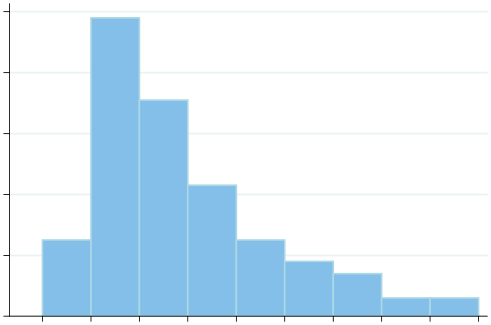

the UI laws of the state in which their employer is headquartered. This disconnect could attenuate our estimates if some of a firm’s workers are located in a different state than the firm’s headquarters. To address this issue, we reestimate Eq. (2) after excluding industries in which a

Panel A: 1950–1960 Panel D: 1980–1990

Panel C: 1970–1980 Panel F: 2000–2009

First quartile Second quartile Third quartile Fourth quartile

Panel B: 1960–1970 Panel E: 1990–2000

Fig. 2. Relative increases in state maximum unemployment insurance (UI) benefits by decade, 1950–2009. This figure displays the quartile of a state’s increase in maximum total benefits, relative to other states in each decade from 1950 to 2009. Larger increases in benefits are shown in darker shades. Maximum total benefits is the product of the statutory maximum weekly UI benefit and the maximum duration and is based on information from annual issues of the US Department of Labor’s ‘‘Significant Provisions of State UI Laws.’’

0

20

40

60

80

100

Frequency

0 25 50 75 100 125 150 175 200 More Percent change in maximum total unemployment insurance benefits

Fig. 3. Distribution of state increases in maximum unemployment insurance (UI) benefits over each decade, 1950–2009. This figure plots the distribution of state increases over each decade from 1950 to 2009 in the maximum total potential benefit available under the state’s unemployment insurance system. The maximum potential benefit is calculated as the product of the statutory maximum weekly UI benefit and the maximum duration and is based on information from annual issues of the US Department of Labor’s ‘‘Significant Provisions of State UI Laws.’’ In all, there are 306 state-decade observations, including the District of Columbia.

A.K. Agrawal, D.A. Matsa / Journal of Financial Economics 108 (2013) 449–470 456

Page 9

[output not shown]

Table 2 Unemployment insurance laws and total state benefit payments.

Fig. 4. Average market leverage and the log of maximum unemployment insurance (UI) benefits by state, 1950–2008. This figure plots average annual state residuals from regressions of market leverage and log max total benefits on year fixed effects from 1950 to 2008. Results for each of the six largest US states are reported. Market leverage is total debt divided by the market value of the firm (data from Compustat). Log max total benefits is the natural log of the product of the statutory maximum weekly UI benefit and the maximum duration and is based on information from annual issues of the US Department of Labor’s ‘‘Significant Provisions of State UI Laws.’’

Page 10

The impact of UI benefits on leverage is also robust to excluding outlier observations. We collapse the sample into state-year observations and analyze corporate leverage ratios as a function of UI benefit laws in median regressions, weighted by the number of underlying observations.<sup>7</sup> The results show that a 100 log point increase in UI benefits leads to a 4.5 percentage point increase in leverage for a given state-year (Column 6). This estimate indicates that the response to UI laws estimated for the full

sample (reported in Columns 1–4) is not driven by extreme observations among UI systems or corporate leverage, but rather reflects the response of a typical firm to reductions in worker unemployment risk.

The value of the tax shield associated with the additional leverage provides another metric for establishing the economic magnitude of the relation between UI laws and corporate leverage. Based on the estimate from Column 4, a

Table 3 Unemployment insurance laws and firms’ capital structures.

This table summarizes the results from firm-panel regressions of total debt divided by assets (market value in Panel A, book value in Panel B) and log interest coverage (Panel C) on the natural log of the maximum total potential benefit available under the state’s unemployment insurance system in the previous year, and a set of controls. Controls in all regressions include year fixed effects. Where shown, controls also include firm fixed effects, state economic indicators (state unemployment rate and state gross domestic product growth rate), and firm financial controls (proportion of fixed assets, market-to-book ratio, natural log of sales, modified Altman Z-score, and return on assets). Where indicated, industries are excluded in which a large percentage of the workforce is likely to be geographically dispersed, namely, retail, wholesale, and transport. Standard errors, adjusted for clustering at the state level, are reported in parentheses. *, **, and *** denote statistical significance at the 10%, 5%, and 1% level, respectively. OLS¼ordinary least squares.

[output not shown]

6 Another possible interpretation we consider is whether serial correlation or another form of modeling error could explain these differences. We evaluate the importance of such factors by randomly simulating UI law changes across sample states and calculating the pvalues of our estimates against the distribution of simulated coefficient estimates. In each of one thousand simulations, we assign the realized paths of state benefit laws to states randomly, so that firms in state A in some simulations are assigned the laws from state B, in others the laws from state C, etc. Our results in this framework have similar statistical significance to those reported in Table 3.

7 The standard errors are calculated using the Markov Chain Marginal Bootstrap method and two hundred repetitions (see He and Hu, 2002).

8 The coefficient on the proportion of fixed assets is 0.235, and the coefficient on the log of sales is 0.032.

A.K. Agrawal, D.A. Matsa / Journal of Financial Economics 108 (2013) 449–470 458

Page 11

100 log point increase in the maximum total UI benefit is associated with 4.8 percentage points greater average leverage. If the average firm faces an interest rate of 10% and marginal tax rate of 25% (Graham, Lemmon, and Schallheim, 1998), then the present value of the incremenal tax shield from increasing leverage by this amount in perpetuity totals approximately 1.2% of the firm’s assets’ value: 4.8% increase in debt/assets 10% interest rate 25% marginal tax rate/10% discount rate¼1.2%. For example, for a $2 billion firm, this amounts to $24 million. Put another way, in 2008, the average Compustat firm had $245,000 in asset value per employee. Thus, the value of the incremenal tax shield associated with a 100 log point increase in the maximum total UI benefit amounts to about $300 in annual wage costs per employee, totaling almost $3,000 per employee in present value (i.e., 1.2% $245,000). Although this calculation is only approximate (for example, it could be an overestimate because it ignores costs of financial distress), it provides a lower bound for the additional wages and benefits that workers require to work for a firm with 4.8 percentage points greater average leverage.<sup>9</sup>

The results are similar in specifications that use book leverage (instead of market leverage) as the dependent variable. Although market leverage is more closely tied to the theoretical hypothesis that firms optimally balance the tax shields of debt with the ex ante costs of worker unemployment risk compensation and the ex post costs of financial distress, many managers may focus on book leverage when making capital structure decisions (Graham and Harvey, 2002). As illustrated in Panel B of Table 3, book leverage increases by up to 4.0 percentage points when UI benefits are increased by 100 log points. The impact of UI laws on book leverage is robust to controls for state macroeconomic conditions and firm financial characteristics, is stronger after excluding industries with dispersed workforces, and is similar in the median regression specification. The first-differences estimate is smaller, suggesting that the impact of UI benefits on book leverage takes longer than a year to be fully realized. These findings suggest that firms actively adjust leverage to account for worker unemployment risk. The results for book leverage also confirm that the observed increases in market leverage around UI law changes are not simply the result of changes in firms’ market values when UI benefits increase.

Finally, although much of the academic literature on leverage focuses on the debt-to-assets ratio, for workers worried about their firm becoming distressed, another important measure of the firm’s financing policy is its interest coverage. Interest coverage, the ratio of operating earnings before depreciation to interest expense, measures the firm’s ability to use its current profits to cover the interest payments due on its outstanding debt. Measuring leverage by interest coverage ratios instead of debt ratios can lead to very different conclusions when a firm is expected to grow. Firms whose cash flows are expected to grow can have low leverage when measured on a debt-to-asset ratio basis

(debt is low relative to future expected cash flows), but high leverage when measured on an interest coverage basis (required interest payments are large relative to current cash flows). The relation between UI benefits and interest coverage is presented in Panel C of Table 3.<sup>10</sup>

We find that, when workers are eligible for greater UI benefits, firms maintain lower interest coverage ratios. The results are both economically and statistically significant: a 100 log point increase in the maximum total UI benefit is associated with 15% lower interest coverage (Column 1). The estimates are similar in specifications that control for local macroeconomic conditions (Column 2), that exclude industries with geographically dispersed workforces (Column 3), and that control for firm performance (Column 4). Results from regressions of first-differences, although not statistically different from the fixed effect results, are much smaller in magnitude, which suggests that interest coverage takes even longer time to adjust to UI benefit changes than other measures of leverage (Column 5). Finally, median regressions show large changes in interest coverage for the average firm in a given state-year (Column 6).

Across all of the specifications in Table 3, we find significant associations between changes in unemployment insurance benefit criteria and firms’ financing policies. Firms appear to increase total debt as a fraction of assets and maintain lower interest coverage when workers are eligible to receive higher benefits from state governments during unemployment. The empirical findings are consistent with the theory that firms boost their financial leverage when workers are better insulated from unemployment risk.

5.2. Identification analysis

One possible alternate explanation for the findings is that unobservable, local economic conditions, such as poor investment opportunities or a high risk of unemployment, lead states to adopt more generous UI laws and also lead firms to increase their borrowing. In this scenario, the relation between UI benefits and financial leverage could be spurious. We explore the empirical relevance of this hypothesis in numerous ways and find evidence suggesting that this explanation is unlikely.<sup>11</sup>

First, controls for local macroeconomic conditions have minimal effect on the estimated association between UI benefits and leverage (see Columns 2–6 of Table 3). In further tests with these controls, we divide the sample period at its midpoint and find remarkably similar results over time. An omitted variable that explains the findings would have to be uncorrelated with these indicators of local economic conditions and also have a consistent impact over time (despite changing macroeconomic environments).

9 If UI benefits do not change, then the reason the firm does not increase its leverage ratio by 4.8% is presumably because the additional wages they would have to pay to compensate workers for the greater risk is greater than the net tax shield and other benefits of the debt issue.

10 Following Faulkender and Petersen (2006), we examine interest coverage in logs to account for the relatively greater importance of equal percentage changes at lower levels of interest coverage. We code interest coverage equal to zero when earnings are negative (the ratio is otherwise not well defined) and take the natural log of one plus interest coverage as the variable of interest.

11 In the interests of space, we present results only for market leverage. Similar results hold for book leverage and interest coverage.

A.K. Agrawal, D.A. Matsa / Journal of Financial Economics 108 (2013) 449–470 459

Page 12

Second, we trace out the timing of the relation between UI benefit changes and financial leverage. If poor, unobserved economic conditions cause firms to increase leverage and induce legislators to raise UI benefits, then one should expect to see increases in leverage before benefits improve. In contrast to this hypothesis, however, Table 4 shows that the inclusion of controls for contemporaneous and forward values of UI benefits in leverage regressions does not attenuate the estimated correlation between lagged UI benefits and corporate leverage ratios. Moreover, the regression coefficients for UI benefits in the current and subsequent years that follow an observed change in leverage are trivial in magnitude and statistically insignificant. These results illustrate that increases in UI benefits are associated with subsequent increases in financial leverage and not vice versa, further mitigating the likelihood of omitted variable bias.

Third, we estimate heterogeneities in our main findings across numerous dimensions, such as labor market characteristics, that are consistent with causality. For an omitted variable to explain the results, in addition to being uncorrelated with our controls for local economic conditions, the omitted variable would have to be correlated with all of the various industry, worker, and firm characteristics for which we find a particularly strong relation between UI benefits and leverage. These analyses are discussed in detail in Sections 5.3 and 5.4.

Fourth, although most Compustat firms have relatively localized production facilities, the revenues of these large, publicly traded firms are typically spread across the country or the world. For such firms with national product markets, unobservable idiosyncratic changes in the economic conditions of the local areas in which they produce are unlikely to have much effect on their borrowing. These firms should illustrate no relation between UI benefits and leverage choices if the observed impact for the full sample is exclusively driven by omitted variables related to local economic conditions. Changes in national economic conditions affect the demand for their goods, which are sold nation- or worldwide, but these are captured by the year fixed effects.

To evaluate the extent to which unobservable, local economic shocks impact our results, we gather data from the 2007 US Commodity Flow Survey (conducted by the US Bureau of the Census) and separate firms based on the fraction of total revenues realized from intrastate versus interstate transactions. If changes in UI laws are driven exclusively by changes in local economic conditions, then the relation between the laws and corporate borrowing should be greatest for firms that generate most of their sales from local, intrastate commerce. In contrast to this hypothesis, we find that the relation between UI generosity and corporate borrowing is as large, if not larger, for subsamples of firms in which a higher fraction of sales are generated out-of-state (results in Table 5). Even when the sample is restricted to industries with more than 85% of sales generated out-of-state, max total UI benefits are associated with a 6.0 percentage point increase in leverage (Column 6).

Fifth, we examine firms’ profits and find no signs of poor operating performance when benefits increase. Regression

estimates of the relation between UI benefits and ROA are reported in Table 6. The specification in Column 1 controls for firm and year fixed effects, Column 2 adds controls for local macroeconomic conditions, Column 3 excludes industries with relatively dispersed workforces, and Column 4 includes controls for firm financial characteristics. Across all four specifications, the level of UI benefits has no significant relation to firms’ operating performance.<sup>12</sup>

These results contradict the notion that unobserved economic conditions lead firms to increase their leverage at the same time that UI benefits improve.

Sixth, we undertake a falsification test in which we examine the relation between firms’ capital structures and the generosity of the UI systems in neighboring states. To the extent that a firm’s operations are concentrated in its headquarters’ state, the generosity of UI benefits in neighboring states should have no direct effect on the firm. However, if unobserved heterogeneity in regional economic conditions is the only determinant of UI benefit laws in the firm’s state, then benefit laws in bordering states are likely to be affected as well.

We include bordering states’ benefit criteria as additional controls in Eq. (2). These controls would attenuate estimates of a1 if unobserved economic conditions drive the UI law changes and leverage adjustments. To the contrary, the results reported in Columns 3 and 4 of Table 4 illustrate that our estimates of the impact of UI benefits on corporate leverage are unaffected by these controls. The coefficient on log max total benefit is the same with and without controls for bordering states’ UI benefits (Columns 1 and 3). Furthermore, even when we exclude controls for the generosity of benefits in the firm’s home state, the relation between bordering states’ benefits and leverage is relatively small and statistically insignificant (Column 4). The relation between home state UI benefits and financing decisions, thus, does not appear to be driven by an omitted regional economic shock.<sup>13</sup>

Finally, the results are robust to using other measures of UI generosity. During periods of high unemployment, it is not uncommon for the government to adjust UI benefits by increasing the duration over which benefits can be drawn. The basic extended benefits program, which was enacted by Congress in 1970, provides up to 13 additional weeks of benefits when a state is experiencing high unemployment.

12 The coefficient estimates also suggest that the state economic indicators we include are effective controls for unobserved economic factors that could be associated with UI laws. For example, when focusing on firms whose workforces are likely locally concentrated, the estimated relation between UI benefits and ROA is less than 0.001 (see Column 3).

13 Similar results are evident from an analysis of the specific historical episodes of clearly exogenous state UI law changes that we describe in Section 3. After California increased UI benefits by 43% in 2002, median firm leverage increased by 5.6%. In contrast, bordering states did not significantly increase UI benefits (median increase in benefits was 1%), and the median change in leverage for firms in bordering states was

6.2%. After New York increased UI benefits by 36% in 1990, median firm leverage increased by 5.4%. Benefits in bordering states remained unchanged and median leverage increased by only 0.7%. Maine’s 12% increase in UI benefits in 2000 was mirrored by only a 5% increase in median UI benefits in bordering states. Maine firms increased leverage by a median rate of 13.9%, while the median firm in bordering states decreased leverage by 7%.

To minimize concerns about omitted variables, we deliberately exclude these extended benefits from our calculations of maximum duration or total potential benefits used in this paper. In untabulated analyses, we also find that the correlations between maximum weekly benefits (or maximum duration) and financial leverage are similar to our main estimates.

5.3. Importance of labor market and worker characteristics

Our hypothesis suggests that increases in UI benefits impact corporate financing decisions through their effects on workers’ exposure to unemployment risk. Because workers face nontrivial costs from unemployment, they require a compensating premium in wages; this premium

Table 4 Falsification tests: timing of capital structure changes and unemployment insurance (UI) laws in bordering states.

This table summarizes the results from falsification tests. Column 1 reproduces the baseline results. Column 2 reports firm-panel regressions of firms’ financial leverage (total debt divided by the market value of the firm) on 1-year lagged, contemporaneous, and 1- year forward values of the natural log of the maximum total potential benefit available under the state’s unemployment insurance system, and a set of controls. Columns 3 and 4 report firm-panel regressions of firms’ financial leverage on the natural log of the maximum total potential benefit available under the state’s UI system in the previous year, the median of the natural log of the maximum total potential benefit available under the UI systems in bordering states, and the controls. Controls in all regressions include firm and year fixed effects, state economic indicators (state unemployment rate and state gross domestic product growth rate), and firm financial controls (proportion of fixed assets, market-to-book ratio, natural log of sales, modified Altman Z-score, and return on assets). Industries are excluded in which a large percentage of the workforce is likely to be geographically dispersed, namely, retail, wholesale, and transport. Standard errors, adjusted for clustering at the state level, are reported in parentheses. *, **, and *** denote statistical significance at the 10%, 5%, and 1% level, respectively.

[output not shown]

NOTE: table converted from PDF layout to HTML text; cell boundaries are reconstructed. See PDF if exact alignment matters.

Table 5 Impact of unemployment insurance laws by geography of sales, national versus local.

This table summarizes the results from firm-panel regressions of firms’ financial leverage (total debt divided by the market value of the firm) on the natural log of the maximum total potential benefit available under the state’s unemployment insurance system in the previous year, and a set of controls. Each column corresponds to different sample restrictions based on the geographic breakdown of sales in the firms’ industry, specifically the percent of the value of product shipments in the firm’s three-digit North American Industry Classification System industry sent to destinations in a different US state and is based on the 2007 Commodity Flow Survey. Controls in all regressions include firm and year fixed effects, state economic indicators (state unemployment rate and state gross domestic product growth rate), and firm financial controls (proportion of fixed assets, market-to-book ratio, natural log of sales, modified Altman Z-score, and return on assets). Industries are excluded in which a large percentage of the workforce is likely to be geographically dispersed, namely, retail, wholesale, and transport. Standard errors, adjusted for clustering at the state level, are reported in parentheses. *, **, and *** denote statistical significance at the 10%, 5%, and 1% level, respectively.

[output not shown]

NOTE: table converted from PDF layout to HTML text; cell boundaries are reconstructed. See PDF if exact alignment matters.

is lower when firms choose conservative financial policies that reduce the risk of financial distress and layoffs. Under this model, we would thus expect to find a stronger relation between UI benefits and corporate financial policies in industries in which labor unemployment risk is more relevant. This subsection evaluates this hypothesis by separately examining industries that differ along various dimensions that proxy for costly worker unemployment risk (see Appendix A for variable definitions).

We first examine industries that vary in the degree of labor intensity in their production technologies. More laborintensive firms face greater aggregate labor costs from increasing leverage because unemployment risks and the associated compensation levels are multiplied across a greater number of workers. Managers of firms that rely more heavily on human capital are thus more likely to take account of worker unemployment costs when making financing decisions.

Second, we evaluate the impact of UI benefits in industries in which workforces exhibit varying degrees of UI payment recipiency. The speed with which workers are able to secure reemployment after a layoff varies across industries, perhaps due to heterogeneous search costs or the demand for specific skills. When workers find employment after a layoff, they are no longer eligible for benefits, and many workers who expect to find work quickly often do not take up benefits at all (Anderson and Meyer, 1997). Firms whose workers are more likely to claim UI benefits after a layoff are, thus, more sensitive to changes in UI laws when making financing decisions.

Third, we exploit cross-industry heterogeneity in the propensity to lay off workers. Historical differences in the long-run propensity for layoffs likely result from structural differences, such as the variability of demand and flexibility of production technologies. To the extent that unemployment

risk aversion is common across workers, it is likely that the effects of UI laws should be especially stark for industries with high layoff rates.

Finally, we examine industries that employ large numbers of low-wage workers and industries in which a small fraction of workers own a home. Browning and Crossley (2001) and Bloemen and Stancanelli (2005) find that the consumption smoothing benefits of UI are concentrated among individuals who have few assets at the time of job loss. Chetty (2008) concludes that 60% of the increase in unemployment durations caused by UI benefits is due to liquidity constraints instead of distortions in job search incentives. UI benefits are thus more likely to affect financing decisions in firms in which many workers receive low wages or most employees do not own homes, as these workers are likely to have limited savings and are especially vulnerable to liquidity constraints after job loss.

We separately estimate the impact of UI law changes on leverage for firms in industries that are above and below the sample median for each of these types of characteristics (results in Table 7). The results for industries with greater (lower) expected worker unemployment costs are reported in Panel A (Panel B). While a 100 log point increase in UI benefits is associated with a 4.7 percentage point increase in leverage among firms in industries with above-median labor intensity (Column 1), it has a smaller effect on firms with low labor intensity (Column 6). The findings are similar whether we split firms on the basis of layoff propensities, UI payment frequencies, or percentages of workers who earn low wages or do not own a home.<sup>14</sup>

Although many of the differences across the samples are not individually statistically significant, the overall pattern of larger estimated relations in Panel A, relative to Panel B, supports the hypothesis that corporate leverage increases when unemployment risk becomes less costly for workers.

5.4. Importance of firm financial constraints

The relation between UI generosity and firms’ financial policies should, according to our hypothesis, also be stronger among financially constrained firms, ceterus paribus. Workers’ concerns about job loss are heightened when firms are unable to raise the external financing needed to buffer negative economic shocks, because many firms respond to performance declines by laying off workers (Ofek 1993; John, Lang, and Netter, 1992). Increased unemployment risk due to financing frictions leads workers to require even higher wage premiums to stay at work and thus places strong pressure on firms to maintain conservative financial policies. UI benefits can ease this pressure by reducing workers’ expected costs of unemployment. To explore these implications, we group firms on the basis of commonly used indicators for financial constraints

Table 6 Unemployment insurance laws and firms’ operating performance.

This table summarizes the results from firm-panel regressions of return on assets on the natural log of the maximum total potential benefit available under the state’s unemployment insurance system in the previous year, and a set of controls. Controls in all regressions include firm and year fixed effects. Where shown, controls also include state economic indicators (state unemployment rate and state gross domestic product growth rate), and firm financial controls (proportion of fixed assets, market-to-book ratio, natural log of sales, modified Altman Zscore, and return on assets). Where indicated, industries are excluded in which a large percentage of the workforce is likely to be geographically dispersed, namely, retail, wholesale, and transport. Standard errors, adjusted for clustering at the state level, are reported in parentheses. None of the reported estimates are statistically significant at the 10% level.

[output not shown]

NOTE: table converted from PDF layout to HTML text; cell boundaries are reconstructed. See PDF if exact alignment matters.

14 One caveat is that other parameters could be correlated with the industry characteristics that we examine. For example, less risk-averse workers might join industries with high layoff rates, thereby weakening the link between UI benefits and leverage for these firms. Though the relative importance of these parameters is ultimately an empirical question, the broad scope of the results in Table 7 lends support to our hypothesis.

and separately examine the relation between UI benefits and leverage for each group.

We start by classifying firms based on their dividend policies. Firms that need to retain all of their capital are more likely to be financially constrained (Fazzari, Hubbard, and Petersen, 1988; Kaplan and Zingales, 1997). We also divide the sample on the basis of operating cash flows, as firms with low cash flows and pledgeable income typically find it difficult to raise external financing (Kaplan and Zingales, 1997), and on the basis of size, as smaller firms are thought to face tighter constraints (Gertler and Gilchrist, 1994; Hadlock and Pierce, 2010).<sup>15</sup>

We separately estimate the impact of UI benefits on leverage for firms with above and below sample median measures of financial constraints (results in Table 8). The relation between UI generosity and financing is particulary strong for zero-dividend firms. A 100 log point increase in the maximum total UI benefit is associated with a 6.1 percentage point increase in leverage (Panel A, Column 1), whereas firms that pay dividends and are less likely to be at risk of financial

distress exhibit a weaker relation between UI benefits and leverage (Panel B, Column 4). The findings are similar when using the other indicators of financial constraints.

Collectively, these findings suggest that firms that face tighter financial constraints are more likely to take into account worker unemployment costs when setting financial policy, as limited access to external financing exacerbates workers’ unemployment risk during difficult economic times. These results further strengthen our conclusion that firms use conservative financial policies partly to mitigate worker exposure to unemployment risk.

6. Alternate mechanisms

6.1. Pure cash flow effect

We also consider alternate explanations for our findings. As described in Section 3, firms pay premiums for their workers’ unemployment insurance. When UI benefits increase, firms’ premium costs increase as well. With less money to pay back debt, these additional costs could weaken firms’ financial positions, increasing leverage and reducing cash and corporate liquidity.

This hypothesis, however, is rejected by the data. As Table 6 indicates, ROA (a proxy for profitability) does not

Table 7 Impact of unemployment insurance (UI) laws by importance of unemployment risk.

This table summarizes the results from firm-panel regressions of firms’ financial leverage (total debt divided by the market value of the firm) on the natural log of the maximum total potential benefit available under the state’s unemployment insurance system in the previous year, and a set of controls. Panel A restricts the sample to industries with greater expected worker unemployment costs (above median labor intensity, above median proportion of workers to collect UI benefits, above median layoff separation rate, above median proportion of workers earning less than $50,000 per year, or below median proportion of workers who own a home), and Panel B restricts the sample to industries with lower expected worker unemployment costs (below median labor intensity, below median UI payments, below median layoffs, below median low wage, or above median home ownership). Labor intensity is measured as the ratio of labor and pension expense to sales (data from Compustat). The proportion of workers collecting unemployment insurance payments is from the Current Population Survey, in which industries are defined at the two-digit Standard Industrial Classification level. The layoff separation rate is measured as the ratio of workers affected by extended mass layoffs to total industry employment and is based on data from the US Bureau of Labor Statistics ‘‘Mass Layoff Statistics’’ and the US Bureau of Economic Analysis. The proportion of low-wage workers and the proportion of home ownership are calculated from the 2000 US population census. Other than for the UI payments, industries are defined at the three-digit North American Industry Classification System level. Controls in all regressions include firm and year fixed effects, state economic indicators (state unemployment rate and state gross domestic product growth rate), and firm financial controls (proportion of fixed assets, market-to-book ratio, natural log of sales, modified Altman Z-score, and return on assets). Standard errors, adjusted for clustering at the state level, are reported in parentheses. *, **, and *** denote statistical significance at the 10%, 5%, and 1% level, respectively.

Panel A: Industries with greater expected worker unemployment costs

[output not shown]

NOTE: table converted from PDF layout to HTML text; cell boundaries are reconstructed. See PDF if exact alignment matters.

15 Firms that face financing constraints could also be different in other ways that affect leverage decisions. For example, if financially constrained firms are less profitable, they may enjoy fewer tax benefits from increased leverage.

decrease significantly when states increase their UI benefits. It is perhaps not surprising that UI benefits do not reduce a firm’s resources on net. Although premium costs increase, workers require less compensation for unemployment risk. In fact, if workers are risk averse and UI premiums are actuarially fair, then more generous unemployment benefits would make firms better off.

6.2. Strategic leverage

Another possibility is that UI benefit laws affect financial policy by impacting workers’ outside options. If greater UI benefits raise the reservation utility of employed workers, then the wage bargaining position of workers could improve, potentially leading firms to raise leverage as means of maintaining a tougher bargaining stance with employees (Bronars and Deere, 1991; Matsa, 2010). The financial policies associated with increases in UI benefits could, therefore, reflect changes in the worker–firm bargaining environment, instead of changes in workers’ unemployment risk.

Unemployment insurance benefits are, however, unlikely to raise the reservation utility of employed workers. An individual who refuses to work because his employer denied him a raise would almost always be ineligible for UI benefits. One exception, however, is for unionized employees in select states. Although eligibility rules generally exclude striking workers from collecting UI benefits, many states allow those unemployed because of a labor dispute to collect unemployment insurance benefits under specific (but rare) conditions.

To evaluate whether the corporate financial policies associated with UI benefit increases reflect changes in the

worker–firm bargaining environment, we repeat our analysis separately for industries with high and low union presence. We classify industries on the basis of the percentage of their workforce covered by collective bargaining agreements in 1983.<sup>16</sup> The bargaining hypothesis predicts that the relation between UI generosity and corporate financial policies should be concentrated among firms in highly unionized industries. In contrast, we find the relation between UI benefits and leverage to be equally strong among firms in low union industries. A 100 log point increase in the maximum total UI benefit is associated with a 5.2 percentage point increase in leverage in industries with high union coverage (standard error 2.5) and a 4.9 percentage point increase in industries with lower union coverage (standard error 2.0). These results are further reinforced by Hamermesh and Wolfe (1990), who find that unionized workers do not receive larger compensating wage differentials for unemployment risk, presumably because unionization is not necessary for workers to receive compensatory wages in full. We conclude that the connection between UI and leverage does not appear to be driven by worker bargaining.

7. Estimates of indirect costs of financial distress

Our analysis thus far measures the impact of partially reducing workers’ unemployment risk on firms’ capital structures through changes in state UI benefit laws. Because UI typically replaces at most half of a worker’s

Table 8 Impact of unemployment insurance laws by importance of financial constraints.

This table summarizes the results from firm-panel regressions of firms’ financial leverage (total debt divided by the market value of the firm) on the natural log of the maximum total potential benefit available under the state’s unemployment insurance system in the previous year, and a set of controls. Panel A restricts the sample to firms that face greater financial constraints (zero dividends, below median operating cash flows, or below median total assets), and Panel B restricts the sample to firms facing fewer financial constraints (positive dividends, above median operating cash flows, or above median total assets). Controls in all regressions include firm and year fixed effects, state economic indicators (state unemployment rate and state gross domestic product growth rate), and firm financial controls (proportion of fixed assets, market-to-book ratio, natural log of sales, modified Altman Z-score, and return on assets). Industries are excluded in which a large percentage of the workforce is likely to be geographically dispersed, namely, retail, wholesale, and transport. Standard errors, adjusted for clustering at the state level, are reported in parentheses. *, **, and *** denote statistical significance at the 10%, 5%, and 1% level, respectively.

Panel A: Firms that face greater financial constraints

[output not shown]

NOTE: table converted from PDF layout to HTML text; cell boundaries are reconstructed. See PDF if exact alignment matters.

16 Industries with at least 25% (less than 25%) of workers covered by collective bargaining are classified as high union (low union). Data on union coverage are from Hirsch and Macpherson (2003) and matched to standard industrial classifications using U.S. Bureau of the Census (1989).

wages, even workers facing a generous UI system still demand a modest wage premium for bearing residual unemployment risk. To measure the full impact of unemployment risk on firms’ financing decisions, this section develops numerical estimates for the present value of excess labor costs associated with leverage choices. These measures capture the ex ante, indirect costs of financial distress that are related to labor unemployment risk.

To estimate these costs, we use default probabilities for each credit rating from Altman (2007) and the wage premium paid per unit of unemployment risk from Topel (1984). For each credit rating, we calculate the additional labor costs that are required to compensate workers for their expected loss in utility should the firm default. For this calculation, the key missing information is the unemployment risk that is associated with financial distress. We calculate the probability of being laid off conditional on default using information on bond defaults from 1977 to 2008 and Compustat.<sup>17</sup> For each default, we gather employment data from Compustat and calculate the percentage change in employment in a window from one year before to one year after the default event.<sup>18</sup> For issuers with multiple defaults, we analyze employment changes around the first event. The results are reported in Table 9, Panel A.

Among the 283 defaulting firms for which employment data are available, employment decreases by approximately 27% in the two years surrounding default. On average, about half of the decrease occurs in the year before default. These estimates are lower bounds because employment reductions are likely to be greater among firms that delist after default and have missing employment data in Compustat. Of such firms, 31 enter bankruptcy. Hotchkiss (1995) finds that the median firm that enters bankruptcy suffers a 50% reduction in employment between the last fiscal year prior to bankruptcy and the first fiscal year after emerging. Applying this estimate in our sample (and dropping the remaining firms with missing data), the average decrease in employment around default is 29%.

To verify that our measures of employment change are related to financial distress, not economic distress, we also examine the contemporaneous change in employment among a matched sample of Compustat firms with similar economic performance within the same two-digit standard industrial classification (SIC) industry as each defaulting issuer. Specifically, for each defaulting firm, we identify a corresponding firm in the same industry with the closest matching ROA in the year prior to default. These matched sample employment changes capture average workforce adjustments that are primarily related to economic distress (under the assumption that economic distress affects each matched set of firms equally).<sup>19</sup> As reported in Panel A, the

average (median) matched sample firms’ employment change is þ3.8% (0%) in the years surrounding default. The estimates across various windows show little sign of economic distress causing layoffs among matched firms. In fact, the positive employment growth among matched firms suggests that we could even be underestimating employment changes related to financial distress.<sup>20</sup>

When a firm increases leverage, it increases the probability of default and exposes workers to a greater probability of job loss. Topel (1984) finds that, for every additional percentage point in unemployment risk, average equilibrium wages increase by 0.93%. This effect is moderated by the unemployment insurance system; Topel (1984) estimates that compensating wage differentials would increase to 2.5% in the absence of UI benefits. The average value of the compensating wage premium, o, per dollar of assets is given by applying the average firm’s labor intensity and capitalizing the annual wage premium, i.e., o

NOTE: contains mathematical notation; text above is the PDF text layer and symbols may be mis-extracted. Image shows the original.

**equation / math rendering (image)**

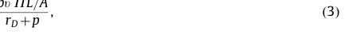

NOTE: contains mathematical notation; text above is the PDF text layer and symbols may be mis-extracted. Image shows the original.

where p is the probability of default, u is the probability of unemployment conditional on default, P is the per unit required wage premium, L is labor expense, A is the market value of assets, and rD is the expected return on debt.<sup>21</sup>

The results in Panel B provide a lower bound for the compensating wage premium, as our employment figures do not capture layoffs that occur in financial distress in the absence of default. Estimates of employment changes near default, reported in Panel A of Table 9, show that firms reduce employment by 16% in the year before default.

17 The default data are from the Altman-NYU Salomon Center Corporate Bond Default Master Database.

18 Compustat data allow us to calculate net changes in employment near a default event. If these firms are also hiring employees during the period, our estimates understate the gross flow out of employment.

19 Indeed, the differences in the firms’ average and median ROA are statistically insignificant.

20 The results are similar when we also limit the control sample to firms with zero leverage.

21 We use the historical default probability (Altman, 2007) and spread over Treasuries (Almeida and Philippon, 2007) associated with each credit rating. The average ratio of annual labor expenses to market value of assets in Compustat from 1950 through 2008 is 25.6%. Following Almeida and Philippon (2007) and others, we assume that the firm maintains a constant leverage ratio (and wage premium) until it defaults, at which point future wage premiums, distress costs, and tax shields are zero.

22 The results in Panel B are also useful for inferring the magnitudes of marginal increases in compensating wage premia as firms increase leverage. For example, a firm moving from an A rating to a BBB rating must incur an additional cost of 51 basis points in firm value to compensate workers for bearing greater unemployment risk.

Distressed firms that are able to avoid default likely reduce employment as well. The full impact of distress-related unemployment risk is, therefore, higher than these estimates imply.

For comparison, we also present estimates of expected ex post costs of financial distress and marginal tax benefits, as reported by Almeida and Philippon (2007), Table 6, based on estimates from Altman (1984), Andrade and Kaplan (1998), Graham (2000), Molina (2005), and their own analysis. Using risk-neutral default probabilities, a BBB rating is associated with ex post financial distress costs of about 4.53% of firm value. The tax benefits associated with a BBB rating are about 5.18% of firm value. The difference between estimated debt tax shields and ex post risk-adjusted costs of financial distress is about 0.65% of firm value. For a BBB-rated firm, our estimates indicate that ex ante compensating wage premiums account for almost 90% of the difference between tax shields and ex post costs of financial distress (i.e., 0.57% of the 0.65% in

firm value).<sup>23</sup> Optimal capital structures are thus likely more conservative than indicated by previous research.

Overall, the results show that the total wage premium tied to unemployment risk and associated with financial leverage represents a significant cost to shareholders. Furthermore, the

Table 9 Estimates of compensation for unemployment risk by credit rating.

This table presents estimates of the ex ante wage costs of firm leverage decisions. Panel A contains statistics that describe employment changes in various windows (measured in years) around default for firms in the Altman-NYU Salomon Center Corporate Bond Default Master Database (1977–2008). Employment changes among comparison firms are also reported, where the comparison firms are the firm with the most similar ratio of operating profit (before interest, taxes, depreciation, and amortization) to assets in the defaulting firm’s two-digit Standard Industrial Classification industry in the year before the default. Panel B presents estimates of wage premium, o, as a percent of the market value of assets, A, required to compensate workers for unemployment risk across various credit ratings and is based on the formula

NOTE: contains mathematical notation; text above is the PDF text layer and symbols may be mis-extracted. Image shows the original.

NOTE: contains mathematical notation; text above is the PDF text layer and symbols may be mis-extracted. Image shows the original.

where p is the probability of default, u is the probability of unemployment conditional on default, P is the per unit required wage premium, L is labor expense, and rD is the expected return on debt. The first column excludes employment changes for bankrupt firms in estimating p. The second and third columns assume a 50% reduction in employment for bankrupt firms for which employment data are unavailable. The second (third) column presents average compensating wage premiums assuming mean (no) UI wage replacement. The fourth and fifth columns present risk-adjusted ex post costs of financial distress and the tax benefits of debt for each credit rating as reported by (Almeida and Philippon, 2007, Table VI).

Panel A: Employment changes around default (percent of employment)

[output not shown]

NOTE: table converted from PDF layout to HTML text; cell boundaries are reconstructed. See PDF if exact alignment matters.

23 These figures are also consistent with the regression estimates reported in Section 5. For an optimizing firm with an A rating, a 4.8 percentage point increase in leverage in response to a 100 log point increase in UI benefits (Table 3, Panel A, Column 4) would decrease the firm’s rating to BBB (Molina, 2005) and yield additional tax savings of about 0.78% and risk-adjusted distress costs of about 0.69% (Almeida and Philippon, 2007). The additional net gain of 0.09% implies that worker’s compensating wages would increase from 0.06% to 0.15% of firm value. Applying this wage figure to Eq. (3) implies that workers’ required premium for each percentage point of unemployment risk (P) decreases from 0.93% to 0.24% when UI benefits increase by 100 log points. This figure is in line with the wage premium–UI benefit relation estimated by Topel (1984), who finds the premium to be 2.5% when there is no unemployment insurance, 0.93% when there are average UI benefits, and 0% when UI provides complete wage replacement.

size of this compensation grows as firms increase leverage and reduce workers’ job security. The estimates indicate that labor unemployment risk is an important determinant of firms’ capital structures, particularly when government-provided unemployment insurance compensation is limited and workers are poorly insured against costly layoff spells.

8. Conclusion

This paper examines the impact of workers’ unemployment risk on corporate financing decisions. Exploiting variation in unemployment insurance benefit levels as shocks to worker unemployment costs, we find that reductions in labor unemployment risk are associated with increases in corporate leverage. Estimates indicate that the average wage compensation for unemployment risk totals about 60 basis points of firm value for a BBB-rated company. The impact of unemployment risk is particularly strong for firms in industries in which layoffs occur with high frequency, for firms that operate with greater labor intensity, and for firms that face tight financial constraints.

The findings illustrate that companies choose conservative financial policies partly as a means of mitigating

workers’ exposure to unemployment risk, supporting models such as Titman (1984) and Berk, Stanton, and Zechner (2010). Reducing leverage decreases the probability that a firm will encounter financial distress and subject workers to costly layoffs. By reducing leverage, managers are able to lower the wage bill required by workers as compensation for bearing unemployment risk.

More broadly, the evidence emphasizes that labor market frictions are an important feature of the corporate environment. Debt policy is but only one of many ways for firms to mitigate workers’ unemployment risk. Firms can also reduce the probability of distress by taking less risky projects (Hennessy and Whited, 2005) or reduce workers’ losses in distress by redesigning job tasks to require fewer firm-specific skills (Jaggia and Thakor, 1994). Exploring the implications of unemployment risk on additional corporate policies is an important area for future research.

Appendix A. Data definitions for subsample analysis (Section 5.3)

Labor intensity: Ratio of labor and pension expenses to sales in Compustat. Measure is based on the three-digit

Table A1 This table lists layoff separation rates for three-digit NAICS industries. The layoff separation rate is the ratio of workers affected by extended mass layoffs to total industry employment, based on data from the US Bureau of Labor Statistics (BLS) ‘‘Mass Layoff Statistics’’ and the US Bureau of Economic Analysis. Extended mass layoffs are defined by the BLS as when at least 50 initial claims are filed against an establishment during a consecutive 5-week period and at least 50 workers have been separated from their jobs for more than 30 days.

[output not shown]

NOTE: table converted from PDF layout to HTML text; cell boundaries are reconstructed. See PDF if exact alignment matters.

Table A1 (continued )

[output not shown]

NOTE: table converted from PDF layout to HTML text; cell boundaries are reconstructed. See PDF if exact alignment matters.

North American Industry Classification System (NAICS) over the full sample period.

UI payment rates: Fraction of workers in the March Current Population Survey that received income from unemployment insurance. Measure is based on two-digit SIC over all years the data are available (1988–2008).

Layoff propensity: Average annual fraction of workers separated from work as part of a mass layoff. Measure uses data from the US Bureau of Labor Statistics (BLS) ‘‘Mass Layoff Statistics’’ and the US Bureau of Economic Analysis (BEA) and is based on three-digit NAICS over all of the years in which the data are available (1996–2008).

We count the number of workers who are separated from their jobs during extended mass layoffs, which is defined by the BLS as when at least 50 initial claims are filed against an establishment during a consecutive 5-week period and at least 50 workers have been separated from their jobs for more than 30 days. For each industry-year, we take the ratio of such separations to total industry employment (from the BEA) and then obtain the industry layoff separation rate by taking the simple average of these ratios over the full sample period.

A listing of the layoff separation rate in each industry is presented in Appendix Table A1. The average layoff separation rate is 1.5% (median is 0.8%), subject to substantial variation across industries. Separation rates are less than 0.1% in seven industries, including real estate, various health care services, and auto parts dealers. The highest separation rates are in agriculture and forestry support activities (18.4%), passenger ground transportation (5.9%), and heavy construction (5.7%).

Low-wage workers: Percentage of workers who earn less than $50,000 in annual income. Measure is based on threedigit NAICS and the 2000 US population census.

Using data from the 1998 Survey of Consumer Finances, we confirm that households with annual income less than $50,000 (in 1999 dollars) have significantly less financial wealth and liquid assets, relative to households with annual income greater than $50,000. The median household with annual income less than $50,000 has financial assets worth 1.56 months of income, and the median household with higher income has financial assets worth 4.63 months of income. Financial assets in this calculation include the sum of all liquid assets (checking and savings accounts, money market deposit accounts, mutual funds, and stocks), bonds (savings, government, and corporate), cash value of life insurance, and other managed assets, such as trusts and annuities, but exclude retirement savings and real estate wealth. Income is defined as the sum of all wage, salary, and investment income.

Given that the US average historical unemployment duration between 1950 and 2008 was 3.2 months (BLS Series ID LNU03008275), these figures suggest that workers who earn less than $50,000 annual income are in a particularly difficult position when they become unemployed. The minimum income required to qualify for maximum UI benefits is typically well below $50,000 (in 1999 dollars), so these workers are impacted by changes in UI benefit ceilings.

Employee home ownership: Percentage of workers that own a home. Measure is based on three-digit NAICS and the 2000 US population census.

References

Abowd, J., Ashenfelter, O., 1981. Anticipated unemployment, temporary

layoffs, and compensating wage differentials. In: Rosen, S. (Ed.), Studies in Labor Markets, University of Chicago Press, Chicago, IL, pp. 141–170. Almeida, H., Philippon, T., 2007. The risk-adjusted cost of financial

distress. Journal of Finance 62, 2557–2586. Altman, E., 1984. A further empirical investigation of the bankruptcy cost

question. Journal of Finance 39, 1067–1089. Altman, E., 2007. About Corporate Default Rates. Special Report, Salomon

Center, New York, NYNew York University. Anderson, P.M., Meyer, B.D., 1997. Unemployment insurance takeup rates

and the after-tax value of benefits. Quarterly Journal of Economics 112, 913–937. Andrade, G., Kaplan, S., 1998. How costly is financial (not economic)

distress? Evidence from highly leveraged transactions that become distressed. Journal of Finance 53, 1443–1493. Asquith, P., Gertner, R., Scharfstein, D., 1994. Anatomy of financial

distress: an examination of junk-bond issuers. Quarterly Journal of Economics 109, 625–658. Bangor Daily News, 1999. Reforming unemployment, April 27, A8. Benmelech, E., Bergman, N., Enriquez, R., 2012. Negotiating with labor under

financial distress. Review of Corporate Finance Studies 1, 28–67. Berk, J., Stanton, R., Zechner, J., 2010. Human capital, bankruptcy, and

capital structure. Journal of Finance 65, 891–926. Berk, J., Walden, J., 2010. Limited capital market participation and human

capital risk. National Bureau of Economic Research working paper 15709. Bertrand, M., Duflo, E., Mullainathan, S., 2004. How much should we trust

differences-in-differences estimates? Quarterly Journal of Economics 119, 249–275. Blaustein, S.J., 1993. Unemployment Insurance in the United States: The

First Half Century. With Wilbur J. Cohen and William Haber. W.E. Upjohn Institute for Employment Research, Kalamazoo, MI. Bloemen, H.G., Stancanelli, E.G.F., 2005. Financial wealth, consumption

smoothing, and income shocks arising from job loss. Economica 72, 431–452. Bronars, S.G., Deere, D.R., 1991. The threat of unionization, the use of debt,

and the preservation of shareholder wealth. Quarterly Journal of Economics 106, 231–254. Brown, J., Matsa, D., 2012. Boarding a sinking ship? An investigation of job

applications to distressed firms. National Bureau of Economic Research working paper 18208. Browning, M., Crossley, T.F., 2001. Unemployment insurance benefit levels

and consumption changes. Journal of Public Economics 80, 1–23. Chemmanur, T., Cheng, Y., Zhang, T., 2009. Capital structure and employee

pay. Unpublished working paper. Boston College. Chen, J., Kacperczyk, M., Ortiz-Molina, H., 2011. Labor unions, operating

flexibility, and the cost of equity. Journal of Financial and Quantitative Analysis 46, 25–58. Chetty, R., 2008. Moral hazard versus liquidity and optimal unemploy-

ment insurance. Journal of Political Economy 116, 173–234. Diamond, P., 1982. Aggregate demand management in search equilibrium.

Journal of Political Economy 90, 881–894. Farber, H.S., 2005. What do we know about job loss in the United States?

Evidence from the displaced workers survey, 1984–2004. Federal Reserve Bank of Chicago Economic Perspectives 29, 13–28. Faulkender, M., Petersen, M.A., 2006. Does the source of capital affect

capital structure? Review of Financial Studies 19, 45–79. Fazzari, S.M., Hubbard, R.G., Petersen, B.C., 1988. Financing constraints

and corporate investment. Brookings Papers on Economic Activity 1, 141–195. Gertler, M.L., Gilchrist, S., 1994. Monetary policy, business cycles, and the

behavior of small manufacturing firms. Quarterly Journal of Economics 109 (2), 309–340. Gibbons, R., Katz, L.F., 1991. Layoffs and lemons. Journal of Labor

Economics 9, 351–380. Gormley, T.A., Liu, H., Zhou, G., 2010. Limited participation and consumption-saving puzzles: a simple explanation and the role of insurance. Journal of Financial Economics 96, 331–344. Graham, J.R., 2000. How big are the tax benefits of debt? Journal of

Finance 55, 1901–1941. Graham, J.R., Harvey, C., 2002. How do CFOs make capital budgeting and

capital structure decisions? Journal of Applied Corporate Finance 15, 8–23. Graham, J.R., Lemmon, M.L., Schallheim, J.S., 1998. Debt, leases, taxes, and

the endogeneity of corporate tax status. Journal of Finance 53, 131–162.

Gruber, J., 1997. The consumption smoothing benefits of unemployment

insurance. American Economic Review 87, 192–205. Hadlock, C.J., Pierce, J.R., 2010. New evidence on measuring financial

constraints: moving beyond the KZ index. Review of Financial Studies 23, 1909–1940. Hamermesh, D.S., Wolfe, J.R., 1990. Compensating wage differentials and

the duration of wage loss. Journal of Labor Economics 8, S175–S197. Harris, M., Holmstrom, B., 1982. A theory of wage dynamics. Review of

Economic Studies 49, 315–333. Harris, M., Raviv, A., 1991. The theory of capital structure. Journal of

Finance 46, 297–355. He, X., Hu, F., 2002. Markov chain marginal bootstrap. Journal of the

American Statistical Association 97, 783–795. Hennessy, C.A., Whited, T.M., 2005. Debt dynamics. Journal of Finance 60,

1129–1165. Hirsch, B.T., Macpherson, D.A., 2003. Union membership and coverage

database from the current population survey: note. Industrial and Labor Relations Review 56, 349–354. Hotchkiss, E.S., 1995. Post-bankruptcy performance and management

turnover. Journal of Finance 50, 3–21. Jaggia, P.B., Thakor, A.V., 1994. Firm-specific human capital and optimal

capital structure. International Economic Review 35, 283–308. Jahoda, M., 1982. Employment and Unemployment: A Social Psychological

Analysis. Cambridge University Press, Cambridge, UK. John, K., Lang, L.H.P., Netter, J., 1992. The voluntary restructuring of large

firms in response to performance decline. Journal of Finance 47, 891–917. Kalil, A., DeLeire, T., 2010. Involuntary job transitions and subjective well-

being in later life. Unpublished working paper. University of Chicago. Kalil, A., Ziol-Guest, K., 2008. Parental job loss and children’s academic

progress in two-parent families. Social Science Research 37, 500–515. Kaplan, S.N., Zingales, L., 1997. Do investment-cash flow sensitivities

provide useful measures of financing constraints? Quarterly Journal of Economics 112, 169–215. Katz, L.F., Meyer, B.D., 1990. The impact of the potential duration of

unemployment benefits on the duration of unemployment. Journal of Public Economics 41, 45–72. Kiplinger California Letter, 2001. Prospects for several California bills.

Kiplinger Washington Editors, Inc., 37(16). Lazear, E.P., 2003. Firm-specific human capital: a skill-weights approach.

Journal of Political Economy 117, 914–940. Li, E.H., 1986. Compensating differentials for cyclical and noncyclical

unemployment: the interaction between investors’ and employees’ risk aversion. Journal of Labor Economics 4, 277–300. MacKie-Mason, J.K., 1990. Do taxes affect corporate financing decisions?

Journal of Finance 45, 1471–1493. Matsa, D.A., 2010. Capital structure as a strategic variable: evidence from

collective bargaining. Journal of Finance 65, 1197–1232. McKinnish, T., 2008. Panel data models and transitory fluctuations in the

explanatory variable. In: Millimet, D.L., Smith, J.A., Vytlaci, E.J. (Eds.), Advances in Econometrics: Modeling and Evaluating Treatment Effects in Econometrics, vol. 21. , Elsevier, Amsterdam, pp. 335–358. Meyer, B.D., 1990. Unemployment insurance and unemployment spells.

Econometrica 58, 757–782. Meyer, B.D., 1995. Lessons from the US unemployment insurance experi-

ments. Journal of Economic Literature 33, 91–131. Meyer, B.D., Mok, W.K.C., 2007. Quasi-experimental evidence on the

effects of unemployment insurance from New York state. National Bureau of Economic Research working paper 12865.

Moffitt, R., 1985. Unemployment insurance and the distribution of unem-

ployment spells. Journal of Econometrics 28, 85–101. Moffitt, R., Nicholson, W., 1982. The effect of unemployment insurance on

unemployment: the case of federal supplemental benefits. Review of Economics and Statistics 64, 1–11. Molina, C., 2005. Are firms underleveraged? An examination of the effect

of leverage on default probabilities. Journal of Finance 60, 1427–1459. Mortensen, D., 1986. Job search and labor market analysis. In: Ashenfelter,

O., Layard, R., Richard, P., Layard, G., Card, D.E. (Eds.), Handbook of Labor Economics, vol. 2. , Elsevier, Amsterdam, pp. 849–919. Mortensen, D., Pissarides, C., 1994. Job creation and job destruction in the

theory of unemployment. Review of Economic Studies 61, 397–415. Myers, S., McConnell, J., Peterson, A., Soter, D., Stern, J., 1998. Vanderbilt

University roundtable on the capital structure puzzle. Journal of Applied Corporate Finance 11, 8–24. New York Times, 1989. Pact reached for 26% rise in jobless pay. S.H.

Verhovek, April 12. Oakland Tribune, 2002. Davis rallies labor, signs bills, raises cash in

Oakland. J. Richman, September 22. Ofek, E., 1993. Capital structure and firm response to poor performance:

an empirical analysis. Journal of Financial Economics 34, 3–30. Opler, T., Titman, S., 1994. Financial distress and corporate performance.

Journal of Finance 49, 1015–1040. Portland Press Herald, 1999. Legislatures work on labor issues. Associated

Press, City, Local, and State March 5, 2B. Rajan, R.G., Zingales, L., 1995. What do we know about capital structure?

Some evidence from international data. Journal of Finance 50, 1421–1460. Rosen, S., 1986. The theory of equalizing differences. In: Ashenfelter, O.,

Card, D. (Eds.), Handbook of Labor Economics, Elsevier, Amsterdam, pp. 641–692. Smith, A., 1976. An inquiry into the nature and causes of the wealth of

nations. In: Campbell, R.H., Skinner, A.S. (Eds.), The Glasgow Edition of the Works and Correspondence of Adam Smith, vol. 2. , Oxford University Press, Oxford, UK. Titman, S., 1984. The effect of capital structure on a firm’s liquidation

decision. Journal of Financial Economics 13, 137–151. Titman, S., Wessels, R., 1988. The determinants of capital structure choice.

Journal of Finance 43, 1–19. Topel, R., Welch, R., 1980. Unemployment insurance: survey and exten-

sions. Economica 47, 351–379. Topel, R.H., 1983. On layoffs and unemployment insurance. American

Economic Review 73, 541–559. Topel, R.H., 1984. Equilibrium earnings, turnover, and unemployment:

new evidence. Journal of Labor Economics 2, 500–522. U.S. Bureau of the Census, 1989. The relationship between the 1970 and

1980 industry and occupation classification systems. Technical paper. US Government Printing Office, Washington, DC. US Congress, US House of Representatives, 2004. 2004 Green Book,

Background Material and Data on Programs within the Jurisdiction of the Committee on Ways and Means. 108th Congress, 2nd session, WMCP: 108-6. US Government Printing Office, Washington, DC. Verwijmeren, P., Derwall, J., 2010. Employee well-being, firm leverage,

and bankruptcy risk. Journal of Banking and Finance 34, 956–964. Wooldridge, J., 2002. Econometric Analysis of Cross Section and Panel

Data, Cambridge, MAMIT Press. Zingales, L., 2000. In search of new foundations. Journal of Finance 55,

1623–1653.